# Visualization

### Loading the required libraries

```r
library(ggplot2)
library(dplyr)
library(Hmisc)
library(psych)
library(tidyr)
```

### Reading the dataset

```r
movie <- read.csv('../Preprocessing/movie_clean.csv', stringsAsFactors = F)
```

### Exploratory Analysis

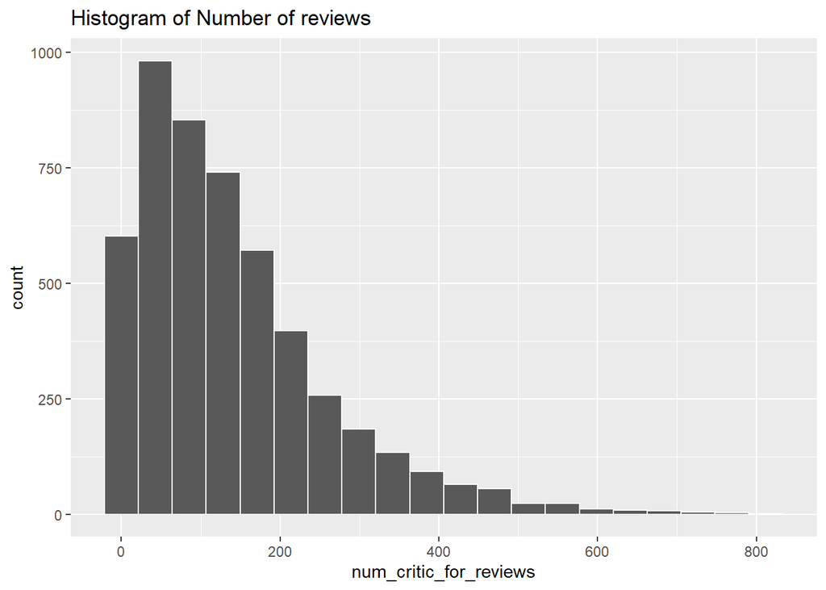

```r
ggplot(aes(x = num_critic_for_reviews), data = movie) + geom_histogram(bins = 20, color = 'white') + ggtitle('Histogram of Number of reviews')
```

```r
summary(movie$num_critic_for_reviews)
```

```
##    Min. 1st Qu.  Median    Mean 3rd Qu.    Max.
##     1.0    50.0   111.0   140.2   194.0   813.0
```

According to this plot most movies have around critic reviews in the range of 50-200

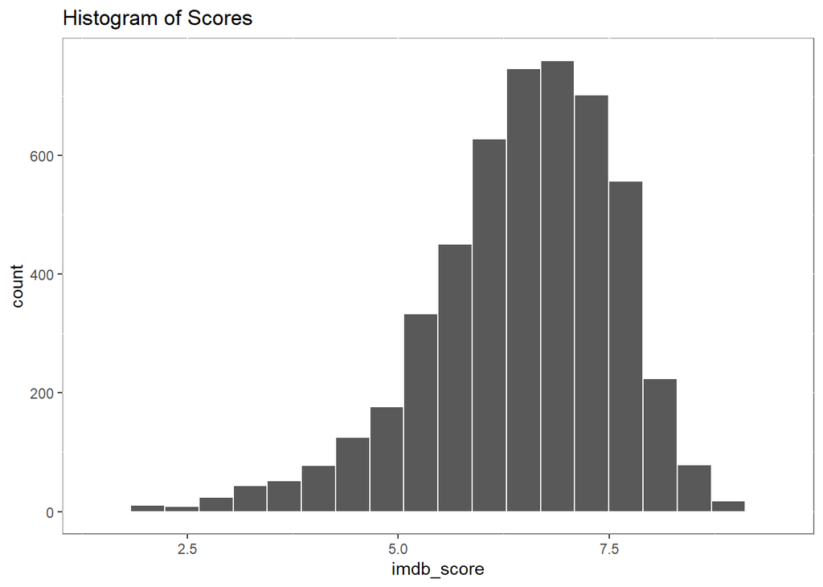

```r
ggplot(aes(x = imdb_score), data = movie) + geom_histogram(bins = 20, color = 'white') + ggtitle('Histogram of Scores') + theme(panel.background = element_rect(fill = "white", colour = "grey50"))
```

Most frequent IMDB scores for movies are in the range 5.0 to 7.5

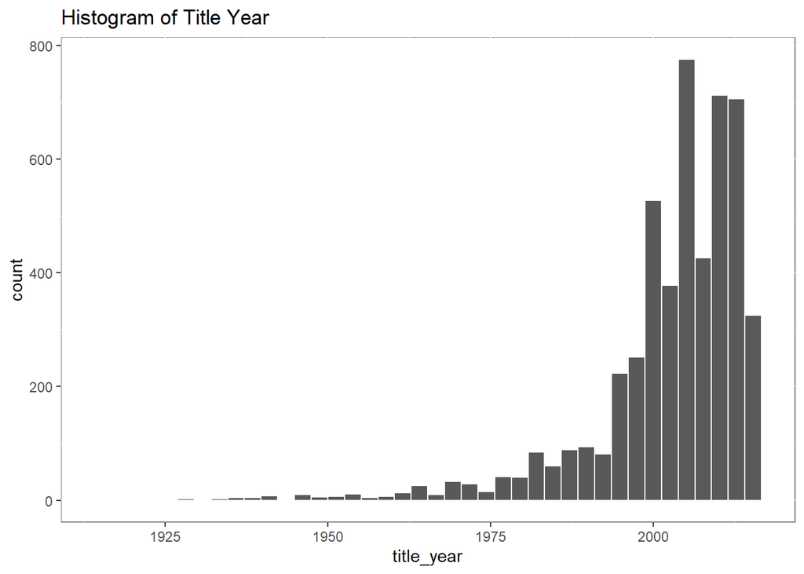

```r
ggplot(aes(x = title_year), data = movie) + geom_histogram(color='white', bins=40) +
  ggtitle('Histogram of Title Year') + theme(panel.background = element_rect(fill = "white", colour = "grey50"))
```

This plot tells us the number of movies produced each year. Most of the movies in this dataset are produced after the year 2000

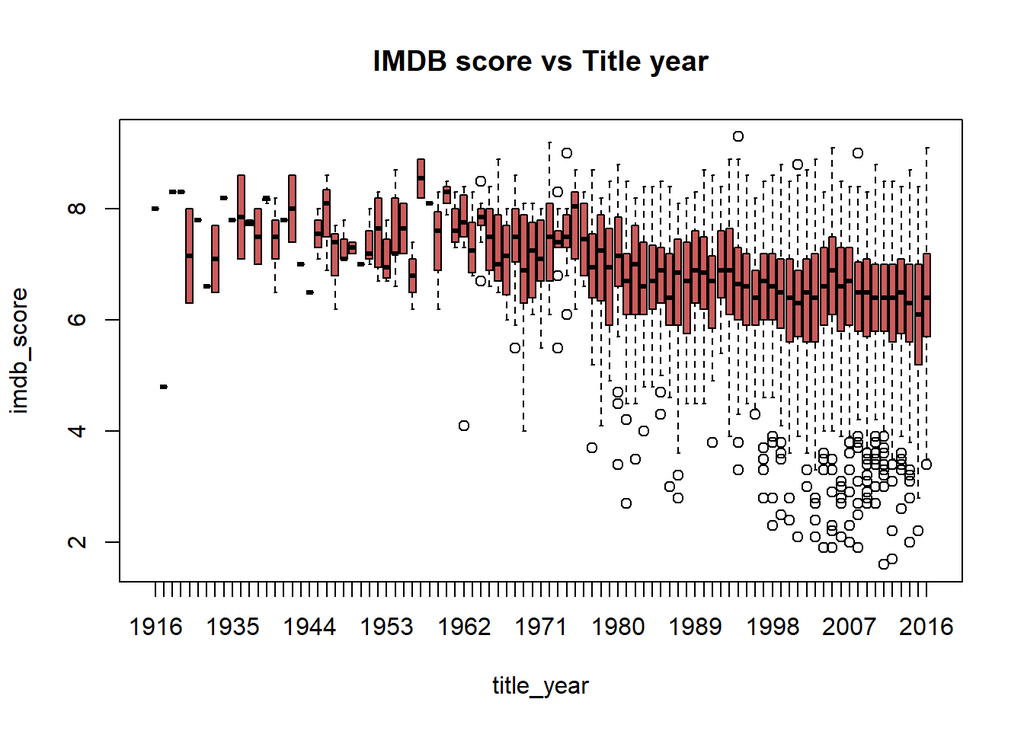

```r
boxplot(imdb_score ~ title_year, data=movie, col='indianred')
title("IMDB score vs Title year")
```

This plot tells us the variation of the IMDB scores over the years. People are ready to give lower scores to movies and this also tells us about the quality of the movies that are being produced. Half a century ago there were only a few players in the movie production market but right now, with the increase of this medium we have seen lots of new producers and directors coming into this market which has led to gradual decrease in the quality of the product with relation to that product.

### Plot of top 10 countries vs number of movies produced

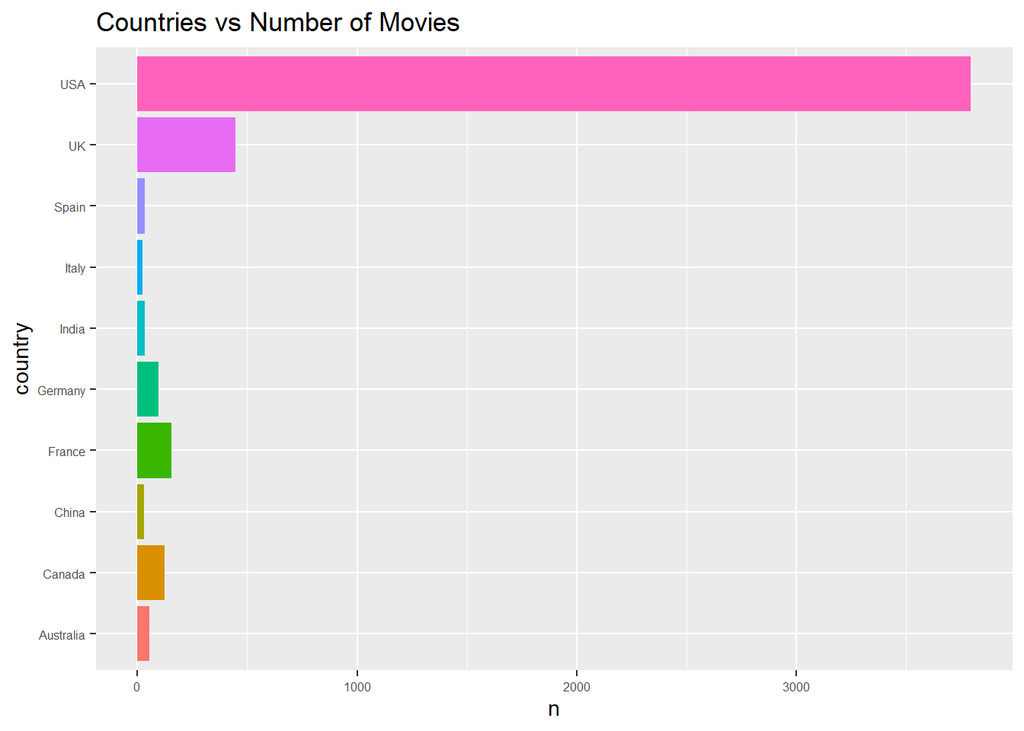

```r
country_group <- group_by(movie, country)
movie_by_country <- summarise(country_group,
                               mean_score = mean(imdb_score),
                               n = n())
aa = movie_by_country[order(-movie_by_country$n), ] %>%
        head(10)
ggplot(aes(x = country, y = n, fill = country), data = aa) + geom_bar(stat = 'identity') + theme(legend.position = "none", axis.text=element_text(size=6)) +
  coord_flip() + ggtitle('Countries vs Number of Movies')
```

The Highest number of movies is produced by the USA

[figure not shown]

```r
aa = movie_by_country[order(-movie_by_country$n), ] %>%
        head(30)
ggplot(aes(x = country, y = mean_score, fill = country), data = aa) + geom_bar(stat = 'identity') + theme(legend.position = "none", axis.text=element_text(size=7)) +
  coord_flip() + ggtitle('Countries vs IMDB Scores')
```

### Top 20 highest-rated movie

```r
movie[order(-movie$imdb_score), ] %>%
  select(movie_title) %>%
    head(20)
```

```
##                                              movie_title
## 1935                          The Shawshank RedemptionÂ
## 3459                                     The GodfatherÂ
## 2818                               DekalogÂ
## 3200                               DekalogÂ
## 4399                              Kickboxer: VengeanceÂ
## 66                                     The Dark KnightÂ
## 2831                            The Godfather: Part IIÂ
## 3474                                 FargoÂ
## 338      The Lord of the Rings: The Return of the KingÂ
## 1872                                  Schindler's ListÂ
## 3348                                      Pulp FictionÂ
## 4487                    The Good, the Bad and the UglyÂ
## 4808                                      12 Angry MenÂ
## 97                                           InceptionÂ
## 270  The Lord of the Rings: The Fellowship of the RingÂ
## 458                              DaredevilÂ
## 682                                         Fight ClubÂ
## 835                                       Forrest GumpÂ
## 1840     It's Always Sunny in PhiladelphiaÂ
## 2049    Star Wars: Episode V - The Empire Strikes BackÂ
```

### Top 20 lowest-rated movie

```r
movie[order(movie$imdb_score), ] %>%
  select(movie_title) %>%
    head(20)
```

```
##                           movie_title
## 2828 Justin Bieber: Never Say NeverÂ
## 1135                     Foodfight!Â
## 2266                 Disaster MovieÂ
## 2293   Superbabies: Baby Geniuses 2Â
## 4594            The Helix... LoadedÂ
## 1727                United PassionsÂ
## 3498              Who's Your Caddy?Â
## 2976           From Justin to KellyÂ
## 3333                        GlitterÂ
## 3657                      CrossoverÂ
## 318                 Son of the MaskÂ
## 4607    Snow White: A Deadly SummerÂ
## 4754                   SubconsciousÂ
## 2190                     Epic MovieÂ
## 2311              Alone in the DarkÂ
## 3518          Chairman of the BoardÂ
## 494               Battlefield EarthÂ
## 898                           GigliÂ
## 2846                  Baby GeniusesÂ
## 4858          Sunday School MusicalÂ
```

### Average movie duration

```r
mean(movie$duration)
```

```
## [1] 107.3348
```

### Count of movies based on language

```r
lang = movie %>%
        group_by(language) %>%
          summarise(n=n())
lang[order(-lang$n), ]
```

```
## # A tibble: 48 x 2
##    language      n
##    <chr>     <int>
##  1 English    4687
##  2 French       73
##  3 Spanish      40
##  4 Hindi        28
##  5 Mandarin     26
##  6 German       19
##  7 Japanese     18
##  8 Cantonese    11
##  9 Italian      11
## 10 Russian      11
## # ... with 38 more rows
```

```r
genres = subset(na.omit(movie), select = c(29:54))

sum = mapply(sum, genres[,]) %>%
        sort(decreasing = TRUE)
```

```r
genre_count = genres %>%
                gather() %>%
                  group_by(key) %>%
                    summarise(value = sum(value==1))
```

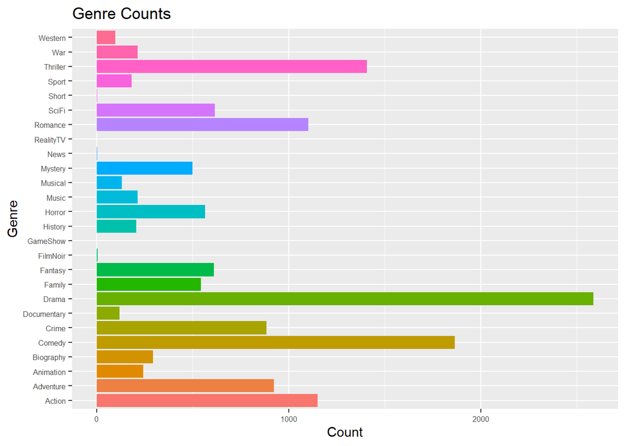

```r
ggplot(genre_count, aes(x=key, y=value, fill=key)) + geom_bar(stat="identity") + theme(legend.position = "none", axis.text=element_text(size=6)) + coord_flip() + ylab("Count") + xlab("Genre") + ggtitle('Genre Counts')
```

Drama is the most produced genre with a count of 2586